# Reproducible Research - Course Project 1

Anu Sambath

December 15, 2017

```r
knitr::opts_chunk$set(echo = TRUE)
options(scipen=999 , digits=2)
```

## Loading the necessary libraries

```r
library(dplyr)
library(ggplot2)
library(scales)
library(lubridate)
```

## Loading and preprocessing the data

- Show any code that is needed to Load the data (i.e. read.csv())
- Process/transform the data (if necessary) into a format suitable for your analysis

```r
### Download the data file
url <- "https://d396qusza40orc.cloudfront.net/repdata%2Fdata%2Factivity.zip"
download.file(url, "./datafiles.zip")
unzip(zipfile = "./datafiles.zip")

activity <- tbl_df(read.csv("./activity.csv"))
activity <- activity %>% mutate ( date = as.POSIXct(date, format="%Y-%m-%d")
)
activity <- activity %>% mutate (interval_start = formatC(interval, width=4, flag="0" ))
activity <- activity %>% mutate (interval_start = paste (substr(interval_start, 1,2) , ":" , substr(interval_start, 3,4) , sep=""))
str(activity)
```

```
## Classes 'tbl_df', 'tbl' and 'data.frame':    17568 obs. of  4 variables:
##  $ steps         : int  NA NA NA NA NA NA NA NA NA NA ...
##  $ date          : POSIXct, format: "2012-10-01" "2012-10-01" ...
##  $ interval      : int  0 5 10 15 20 25 30 35 40 45 ...
##  $ interval_start: chr  "00:00" "00:05" "00:10" "00:15" ...
```

## What is mean total number of steps taken per day?

- For this part of the assignment, you can ignore the missing values in the dataset.
- Calculate the total number of steps taken per day
- If you do not understand the difference between a histogram and a barplot, research the difference between them. Make a histogram of the total number of steps taken each day
- Calculate and report the mean and median of the total number of steps taken per day

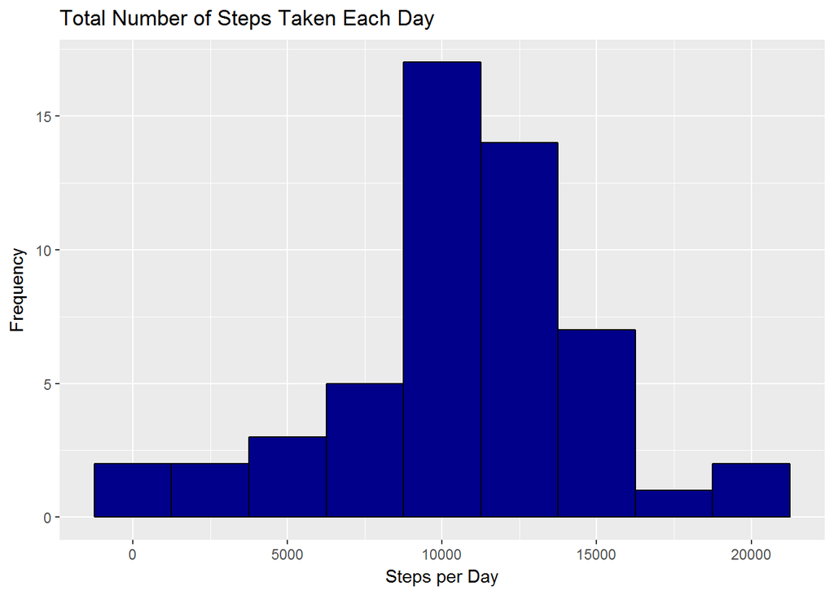

```r
Steps_Per_Day <- aggregate(steps ~ date, activity, sum, na.rm=TRUE)
g <- ggplot(Steps_Per_Day, aes(steps ))

g <- g + geom_histogram(binwidth =2500 , col="black", fill="dark blue") +
    xlab("Steps per Day")  +
    ylab("Frequency") +
    ggtitle("Total Number of Steps Taken Each Day")

print (g)
```

```r
mean_steps <- mean(Steps_Per_Day$steps)
median_steps <- median(Steps_Per_Day$steps)
```

- The mean of the total number of steps taken per day is **10766.19**.
- The median of the total number of steps taken per day is **10765**.

## What is the average daily activity pattern?

- Make a time series plot (i.e. type = “l”) of the 5-minute interval (x-axis) and the average number of steps taken, averaged across all days (y-axis)
- Which 5-minute interval, on average across all the days in the dataset, contains the maximum number of steps?

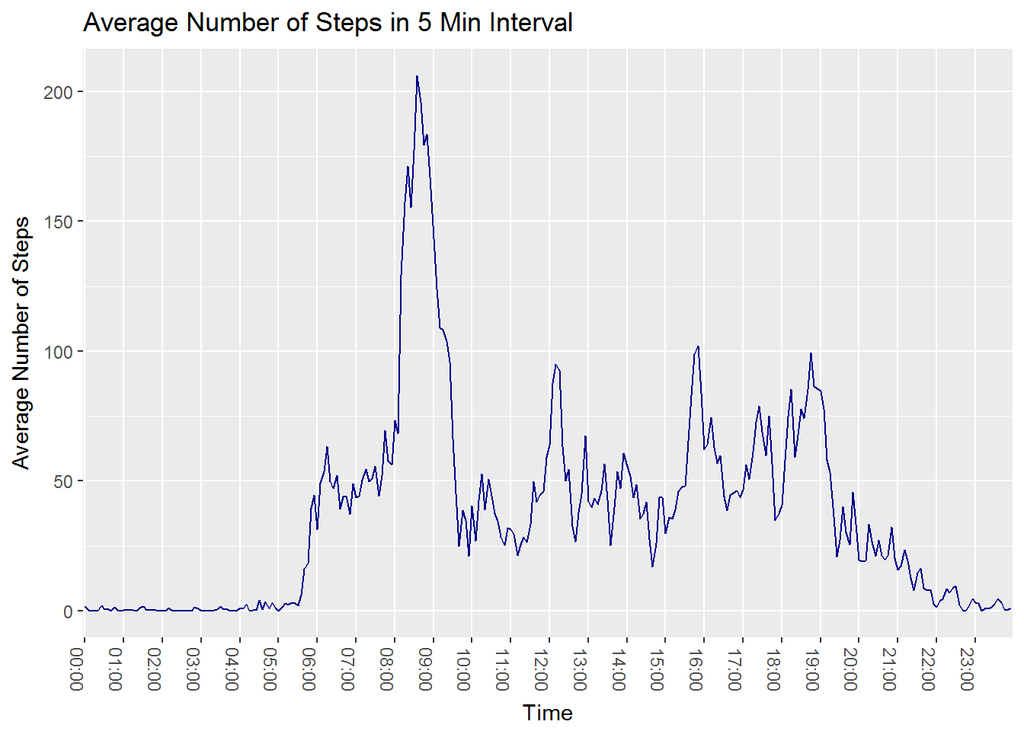

```r
Steps_By_Interval <- aggregate(steps ~ interval_start, activity, mean, na.rm=TRUE)
v <- c(1:289)
breaks <- (v%%12) == 1
breakpoints <- Steps_By_Interval$interval_start[breaks]
g <- ggplot(Steps_By_Interval, aes(x=interval_start, y=steps , group=1))
g <- g + geom_line(col="darkblue") +
    xlab("Time")  +
    scale_x_discrete(breaks = breakpoints ) +
    theme(axis.text.x=element_text(angle = -90, hjust = 0)) +
    ylab("Average Number of Steps") +
    ggtitle("Average Number of Steps in 5 Min Interval")
print(g)
```

```r
Interval_with_max_steps <- Steps_By_Interval[which.max(Steps_By_Interval$steps),]$interval_start
```

The 5 min interval that contains the maximum number of steps, on an average across all the days in the dataset, starts at **08:35**.

## Imputing missing values

```r
Total_missing_rows <- sum(is.na(activity$steps))
```

Total number of missing values in original dataset is **2304**.

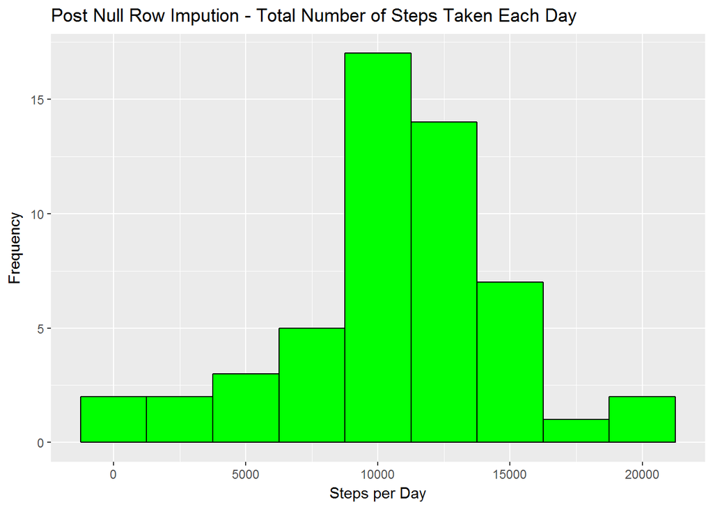

```r
imputed_steps <-  activity %>%
    mutate ( steps = ifelse (is.na(steps), Steps_By_Interval$steps[match(activity$interval, Steps_By_Interval$interval)] , steps ) )

imp_Steps_Per_Day <- aggregate(steps ~ date, imputed_steps, sum, na.rm=TRUE)

g <- ggplot(imp_Steps_Per_Day, aes(steps ))

g <- g + geom_histogram(binwidth =2500 , col="black", fill="green") +
    xlab("Steps per Day")  +
    ylab("Frequency") +
    ggtitle("Post Null Row Impution - Total Number of Steps Taken Each Day")
print(g)
```

```r
imp_mean_steps <- round(mean(imp_Steps_Per_Day$steps), digits=2)
imp_median_steps <- round(median(imp_Steps_Per_Day$steps), digits=2)
```

## Are there differences in activity patterns between weekdays and weekends?

- For this part the weekdays() function may be of some help here. Use the dataset with the filled-in missing values for this part.
- Create a new factor variable in the dataset with two levels - “weekday” and “weekend” indicating whether a given date is a weekday or weekend day.
- Make a panel plot containing a time series plot (i.e. type = “l”) of the 5-minute interval (x-axis) and the average number of steps taken, averaged across all weekday days or weekend days (y-axis).

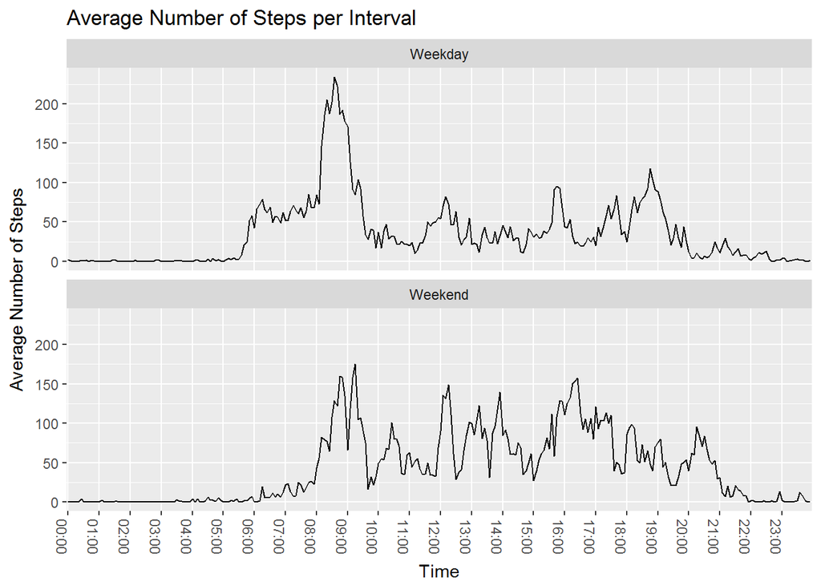

```r
 imputed_steps <- imputed_steps %>% mutate (day = ifelse(weekdays(as.Date(date) )%in% c("Saturday", "Sunday"), "Weekend", "Weekday"))

Steps_By_Interval_day <- aggregate(steps ~ interval_start+day, imputed_steps, mean, na.rm=TRUE)

g <- ggplot(Steps_By_Interval_day, aes(x=interval_start, y=steps , group=1))
g <- g + geom_line()  +
    facet_wrap( ~ day , ncol=1 ) +
    xlab("Time")  +
    scale_x_discrete(breaks = breakpoints ) +
    theme(axis.text.x=element_text(angle = -90, hjust = 1)) +
    ylab("Average Number of Steps") +
    ggtitle("Average Number of Steps per Interval")
print(g)
```